# HW#2

Karen Mkhitaryan

June 29, 2018

In this homework you will work on video games dataset containing information about popular video games, their sales in North America, Europe, Japan and globally in the world. In the dataset ratings by critics and users are presented and ratings of the games.

## Solve the problems and submit the .Rmd file.

WARNINGS!!! (If not done you will lose points.) 1) Make sure to put titles on the plots and texts on axes. 2) If the plot is not interpretable, zoom on “x” or “y” axes to make the graph more interpretable (P4,P5, P7 and P8). ——————————————————–

# P1)

Import the dataframe in R and with the use of dplyr subset it using the following information.

-remove columns Publisher, JP_Sales (Sales in Japan), Critic_Count, User_Count and Developer. (1p) -Multiply the numbers in NA_Sales, EU_Sales and GP_Sales by 1 million as they are given in millions of sales. (1p) -include only those for which NA_Sales>=20000, EU_Sales>=20000 and Ranking is among Everyone(“E”),Mature(“M”), Teen(“T”), Everyone 10+(“E10+”) and Adults Only (“AO”). (1p)

```r
video_games <- read.csv("Video_Games.csv", stringsAsFactors = F)

library(dplyr)
library(tidyverse)
games <- video_games %>%
  select(-c(Publisher, JP_Sales, Critic_Count, User_Count, Developer)) %>%
  mutate(NA_Sales = video_games$NA_Sales * 1000000,
         EU_Sales = video_games$EU_Sales * 1000000,
         Global_Sales = video_games$Global_Sales * 1000000) %>%
  filter(NA_Sales >= 20000, EU_Sales >= 20000,
         Rating =='E' | Rating == 'M' | Rating == 'T' | Rating == 'E10+' | Rating == 'AO')
```

# P2)

Use data cleaning tools to clean the data.

1. Look at the columns which are either numeric or integer. Make sure they contain only numbers or NA’s (nothing else). (1p)
2. Critic scores can be from 0 to 100 and users scores from 0 to 10. If there are values not from these intervals clean that observations using ifelse statement. (2p)
3. Look at the Genres: check if all categories are unique and if not, clean them so that there are no duplicate names. (2p)

```r
str(games)
```

```
## 'data.frame':    6145 obs. of  10 variables:
##  $ Name        : chr  "Wii Sports" "Mario Kart Wii" "Wii Sports Resort" "New Super Mario Bros." ...
##  $ Platform    : chr  "Wii" "Wii" "Wii" "DS" ...
##  $ Year        : chr  "2006" "2008" "2009" "2006" ...
##  $ Genre       : chr  "Sports" "Racing" "Sports" "Platform" ...
##  $ NA_Sales    : num  41360000 15680000 15610000 11280000 13960000 ...
##  $ EU_Sales    : num  28960000 12760000 10930000 9140000 9180000 ...
##  $ Global_Sales: num  82530000 35520000 32770000 29800000 28920000 ...
##  $ Critic_Score: int  76 82 80 89 58 87 91 80 61 80 ...
##  $ User_Score  : chr  "8" "8.3" "8" "8.5" ...
##  $ Rating      : chr  "E" "E" "E" "E" ...
```

```r
sapply(games, class)
```

```
##         Name     Platform         Year        Genre     NA_Sales
##  "character"  "character"  "character"  "character"    "numeric"
##     EU_Sales Global_Sales Critic_Score   User_Score       Rating
##    "numeric"    "numeric"    "integer"  "character"  "character"
```

```r
unique(games$User_Score)
```

```
##  [1] "8"   "8.3" "8.5" "6.6" "8.4" "8.6" "7.7" "6.3" "7.4" "8.2" "9"
## [12] "7.9" "8.1" "8.7" "7.1" "3.4" "5.3" "4.8" "3.2" "8.9" "6.4" "7.8"
## [23] "7.5" "2.6" "7.2" "9.2" "7"   "7.3" "4.3" "7.6" "5.7" "5"   "9.1"
## [34] "6.5" "tbd" "8.8" "6.9" "9.4" "6.8" "6.1" "6.7" "5.4" ""    "4"
## [45] "4.9" "4.5" "6.2" "4.2" "6"   "3.7" "4.1" "5.8" "5.6" "5.5" "4.4"
## [56] "4.6" "5.9" "3.9" "9.3" "3.1" "2.9" "5.2" "3.3" "4.7" "5.1" "3.5"
## [67] "2.5" "1.9" "3"   "2.7" "2.2" "2"   "9.5" "2.1" "3.6" "2.8" "1.8"
## [78] "3.8" "1.6" "9.6" "2.4" "1.7" "1.5" "999" "0.7" "1.2" "0.2" "0.5"
```

```r
unique(video_games$Year)
```

```
##  [1] "2006" "1985" "2008" "2009" "1996" "1989" "1984" "2005" "1999" "2007"
## [11] "2010" "2013" "2004" "1990" "1988" "2002" "2001" "2011" "1998" "2015"
## [21] "2012" "2014" "1992" "1997" "1993" "1994" "1982" "2016" "2003" "1986"
## [31] "2000" "N/A"  "1995" "1991" "1981" "1987" "1980" "1983" "2020" "2017"
```

```r
games$User_Score <- as.numeric(games$User_Score)
games$Year <- as.numeric(games$Year)
summary(games$Year)
```

```
##    Min. 1st Qu.  Median    Mean 3rd Qu.    Max.    NA's
##    1992    2004    2007    2007    2011    2016      99
```

```r
summary(games$Critic_Score)
```

```
##    Min. 1st Qu.  Median    Mean 3rd Qu.    Max.    NA's
##   17.00   63.00   73.00   71.62   81.00  999.00     709
```

```r
games$Critic_Score <- ifelse(games$Critic_Score > 100, NA, games$Critic_Score)
summary(games$Critic_Score)
```

```
##    Min. 1st Qu.  Median    Mean 3rd Qu.    Max.    NA's
##   17.00   63.00   73.00   70.94   81.00   98.00     713
```

```r
summary(games$User_Score)
```

```
##    Min. 1st Qu.  Median    Mean 3rd Qu.    Max.    NA's
##   0.200   6.500   7.600   8.004   8.300 999.000     949
```

```r
games$User_Score <- ifelse(games$User_Score > 10, NA, games$User_Score)
summary(games$User_Score)
```

```
##    Min. 1st Qu.  Median    Mean 3rd Qu.    Max.    NA's
##   0.200   6.500   7.600   7.241   8.300   9.600     953
```

```r
unique(games$Platform) #looks ok
```

```
##  [1] "Wii"  "DS"   "X360" "PS3"  "PS2"  "3DS"  "PS4"  "PS"   "XB"   "PC"
## [11] "PSP"  "WiiU" "GC"   "GBA"  "XOne" "PSV"  "DC"
```

```r
unique(games$Genre) # repeating names (uppercase problem)
```

```
##  [1] "Sports"       "Racing"       "Platform"     "Misc"
##  [5] "Action"       "Puzzle"       "Shooter"      "Fighting"
##  [9] "Simulation"   "Role-Playing" "SHooter"      "   Sports"
## [13] "Adventure"    "Strategy"     "ACTION"       "SPORTS"
```

```r
games$Genre <- toupper(games$Genre)
unique(games$Genre) #spaces yo
```

```
##  [1] "SPORTS"       "RACING"       "PLATFORM"     "MISC"
##  [5] "ACTION"       "PUZZLE"       "SHOOTER"      "FIGHTING"
##  [9] "SIMULATION"   "ROLE-PLAYING" "   SPORTS"    "ADVENTURE"
## [13] "STRATEGY"
```

```r
games$Genre <- trimws(games$Genre)
unique(games$Genre)
```

```
##  [1] "SPORTS"       "RACING"       "PLATFORM"     "MISC"
##  [5] "ACTION"       "PUZZLE"       "SHOOTER"      "FIGHTING"
##  [9] "SIMULATION"   "ROLE-PLAYING" "ADVENTURE"    "STRATEGY"
```

# P3)

Create a scatterplot displaying how User scores and Critics score are interconnected -make the point shape triangle, color red and transperancy 20%. Explain what you see in the graph. (1p)

# P4)

Construct a graph showing how the global sales of the game is dependent of a score given by the user and explain what you see in the graph. (Hint! ?options to display values without “e” short notation) (1p)

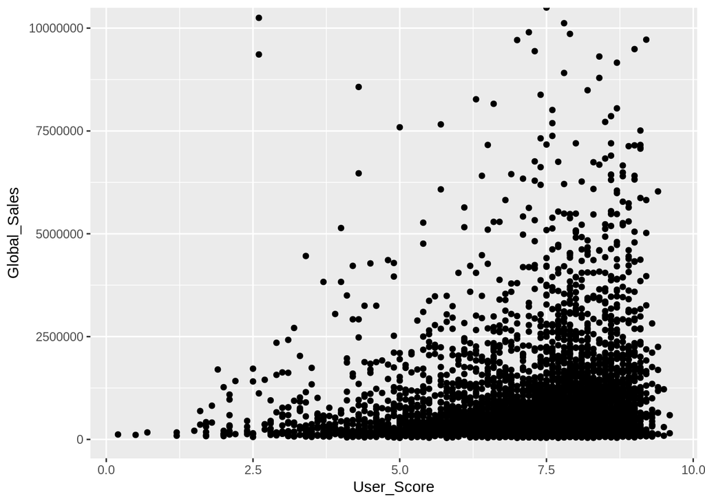

```r
options(scipen=10000)
ggplot(games, aes(x = User_Score, y = Global_Sales)) + geom_point() +
    coord_cartesian(ylim = c(40000,10000000))
```

```r
# we can see a linear regression with some mistakes
```

# P5)

Make previous plot more appealing using the following. (1p) -x axis name – “Score given by the User” color red, bold size=15 -y axis name – “Global Sales of the game” color red, bold size=15 -points (shape - square, color-red, size- 1.5) -title of the plot – “User Score versus Global Sales” - Make panel background color #09f2d5 - axis texts bold black

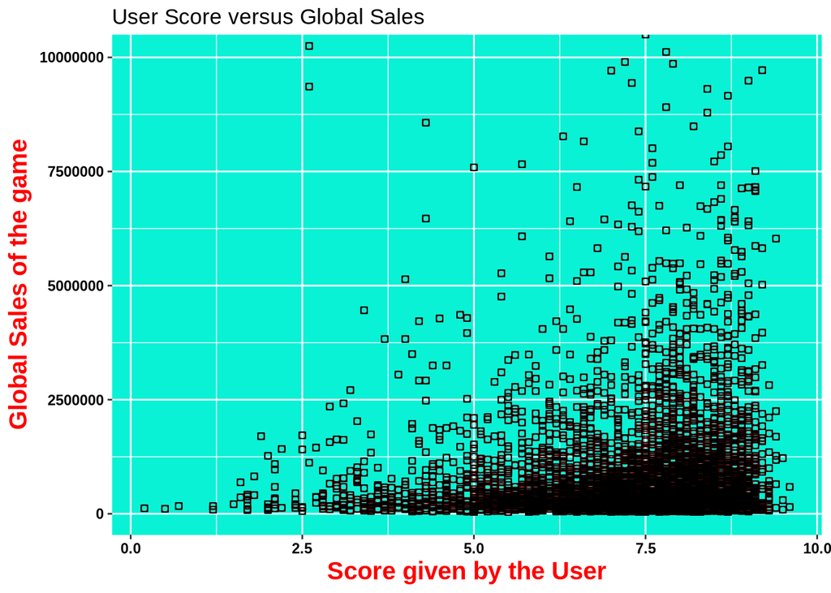

```r
ggplot(games, aes(x = User_Score, y = Global_Sales)) + geom_point(color="red", shape = 1) +
  coord_cartesian(ylim = c(40000,10000000)) +
  labs(x="Score given by the User", y = "Global Sales of the game", title = "User Score versus Global Sales") +
  theme(axis.title.x = element_text(size = 15, color = "red", face = "bold"),
        axis.title.y = element_text(size = 15, color = "red", face = "bold"),
        axis.text = element_text(face = "bold", color = "black"),
        panel.background = element_rect(fill="#09f2d5")) +
  geom_point(color="black", shape = 0, size =1.5) +
  coord_cartesian(ylim = c(40000,10000000))
```